### handwritten digits recognizer with deep learning - MNIST Data

```
library(h2o)
library(plyr)
library(ggplot2)
```

這篇將實作深度學習於手寫數字的辨識，利用著名的 MNIST 資料集，可直接從 kaggle 網站 [Digit Recognizer](https://www.kaggle.com/c/digit-recognizer) 下載，訓練資料共 42000 筆、785 個欄位(1個label、784個pixels)，將利用這些資料訓練、建模和預測。這次介紹的重點在於 Computer Vision(CV) 基本處理及 Deep Learning 的應用(利用H2O套件)，它有 Multi CPU、Cluster 運算和 Auto-Encoder，但沒有支援CNN、RNN，因此這篇主要以DNN方法為主…

#### **Quick-Start**

H2O的核心碼是Java，因此R套件h2o在安裝前必須先安裝JVM和JDK，考量後續的執行效能，建議安裝64 bit的，待一切備妥後，透過下列指令啟動H2O server，nthreads = -1 表示將使用多核運算。啟動之後，預設可以透過瀏覽器輸入網址 http://127.0.0.1:54321 查看H2O FLOW，這是一個很棒的web操作介面(如下圖)，從檔案的匯入、資料框架的查看和異動、模型的匯入建立等等，都可以透過介面完成

```r
# using all your cores
h2o.init(nthreads = -1)
```

[figure not shown]

H2O有自己的H2O Frame，它是在H2O Server裡進行運算的(不是在R的client)，概念上和Spark很相似，透過 h2o.importFile 可以直接將檔案匯入轉成 H2O Frame，由於我把H2O安裝在單機，考量硬體效能及匯入後加工處理的便利性，這裡還是先以 read.csv 讀入檔案…後續再利用 as.h2o 來轉換

```r
# 匯入
train_data <- read.csv(file.path("data", "digit_recognizer","train.csv"), stringsAsFactors = F)
train_data$label <- as.factor(train_data$label)
```

#### **Take A Look**

這案例除了應用深度學習來分類之外，另一個重點在於基本CV的練習，由於原始資料已經很乾淨了，甚至沒有missing data，因此接下來除了一窺原始pixels的圖片，我也利用減少一列(欄)進行上下左右移動再平均的做法，當作和原始資料應用上的比較

```r
# 移動平均
moveAVG <- function(row_df){
  row_vt <- as.vector(as.matrix(row_df))
  reflected_mx <- matrix(row_vt, 28, 28)
  img_mx <- reflected_mx[, 28:1]
  # ---
  # 位移1row,1col
  zoro_r <- matrix(0, nrow = 1, ncol = 28)
  zoro_c <- matrix(0, nrow = 28, ncol = 1)
  # move up + move down
  img_up <- rbind(img_mx[-1, ], zoro_r)
  img_dw <- rbind(zoro_r, img_mx[-28, ])
  img_Ver <- (img_up + img_dw) / 2
  # move left + move right
  img_lt <- cbind(img_mx[,-1], zoro_c)
  img_rt <- cbind(zoro_c, img_mx[,-28])
  img_Hor <- (img_lt + img_rt) / 2
  # 合併平均
  img_Move <- (img_Ver + img_Hor ) / 2
  return(as.vector(img_Move[,28:1]))
}

train_moveAVG <- apply(train_data[,-1], 1, moveAVG)
train_moveAVG <- t(train_moveAVG)
# add label
train_moveAVG <- data.frame(label=train_data[,1], train_moveAVG)
```

以前10筆資料為例，上列是原始pixels的圖片，下列是上下左右移動再平均後的圖片

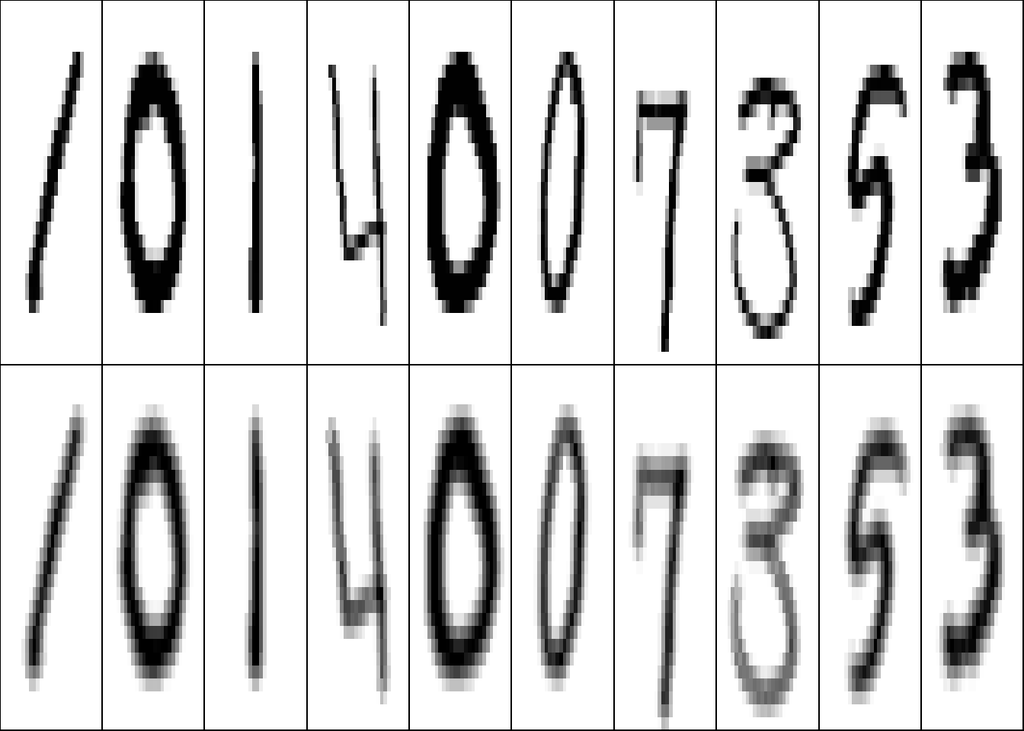

#### **Experiments (DNN)**

接下來針對以上2種資料來實驗，試試DNN的分類成效，訓練和測試資料比為8:2，每一種資料將實驗2次，一次採預設參數、一次採用自訂的tuning參數，為了後續重複使用，實驗函式如下

```r
# deep learning
startDL <- function(h2odata_v) {
  result_df = ldply(h2odata_v, function(h2odata) {
    y <- "label"
    x <- setdiff(names(h2odata),    y)
    parts <- h2o.splitFrame(h2odata,    0.8, seed=777)
    train <- parts[[1]]
    test <- parts[[2]]
    # default
    t1 = Sys.time()
    m_D <- h2o.deeplearning(x, y,   train, model_id =   "DL:200*200_10", seed = 777)
    mse_D = h2o.mse(m_D)
    p_D <- h2o.predict(m_D, test)
    acc_D = mean(test$label == p_D$predict)
    # tuning
    m_T <- h2o.deeplearning(x, y, train, model_id   =   "DL:500*300_50", distribution = "multinomial",
                            sparse = T, epochs = 50, seed = 777, l1 =   0.00001,
                            input_dropout_ratio =   0.25,   hidden_dropout_ratios   =   c(0.5, 0.3),
                            activation = "RectifierWithDropout", hidden = c(500, 300))
    mse_T = h2o.mse(m_T)
    p_T <- h2o.predict(m_T, test)
    acc_T = mean(test$label == p_T$predict)
    print(difftime(Sys.time(), t1, units = 'mins'))

    return(c(mse_default = mse_D,  acc_default = acc_D, mse_tuning = mse_T, acc_tuning = acc_T))
  })
  return(result_df)
}
```

將原始資料及移動後的平均資料轉成H2O Frame，進行第一次的DNN實驗，結果第一列為使用原始資料、第二列則是使用移動後的平均資料，從下面的結果看來，第一列無論是預設或tuning參數所得的mse都比較低(好)，不過在accuracy表現上，第一列和第二列都差不多，不過兩者在tuning參數下所得的accuracy都比使用預設的高(約1%)

```r
h2o_t0 <- as.h2o(train_data)
h2o_t1 <- as.h2o(train_moveAVG)
performance <- startDL(list(h2o_t0, h2o_t1))
```

```
##   mse_default acc_default  mse_tuning acc_tuning
## 1 0.001110754   0.9672526 0.001630088  0.9798941
## 2 0.004856237   0.9697809 0.004449035  0.9797737
```

#### **Experiments (DNN + Feature Engineering)**

由於上面所得到accuracy相近，接下來繼續透過基本CV方法來增加資料的features，看看能否有所改善。首先，增加avgBlock函式，針對所傳入的matrix進行block的平均，以4x4 grid為例，將可以得到49個features (784/16)

```r
# 平均block值, default 2x2 grid
avgBlock <- function(data_mx, n = 2) {
  index <- n
  limt <- sqrt(length(as.vector(data_mx)))
  mb <- c()

  for (k in seq(1, limt, by = index)) {
    for (i in seq(1, limt, by = index)) {
      k2 <- k + index - 1
      i2 <- i + index - 1
      if (i2 <= limt && k2 <= limt) {
        avg = mean(data_mx[i:i2, k:k2])
        mb <- c(mb, avg)
      }
    }
  }
  return(mb)
}
```

另外，考量列、欄的平均值在不同數字上有所分別，以下採用2列、欄的平均做為新增的features，這樣又可以產生28個(14+14)

```r
# 添加img features
addFeatures <- function(row_df){
  row_vt <- as.vector(as.matrix(row_df))
  reflected_mx <- matrix(row_vt, 28, 28)
  img_mx <- reflected_mx[, 28:1]
  # 2 col,row 平均
  avg2c_mv <- sapply(seq(1, 28, by = 2), function(i) mean(img_mx[i:i+1,]))
  avg2r_mv <- sapply(seq(1, 28, by = 2), function(i) mean(img_mx[,i:i+1]))

  # 平均 grid nxn 產生block
  mean_block <- avgBlock(img_mx, 4)

  return(c(avg2c_mv, avg2r_mv, mean_block))
}
```

接著，將原始和移動後的平均資料分別帶入上述函式，將產生共77個新的features，然後將這些併入原本的資料中，資料維度將增加到862(785+77)，後續利用這些資料來實驗

```r
train_data_add <- apply(train_data[,-1], 1, addFeatures)
train_data_add <- t(train_data_add)
dim(train_data_add)

train_moveAVG_add <- apply(train_moveAVG[,-1], 1, addFeatures)
train_moveAVG_add <- t(train_moveAVG_add)

# 添加features
h2o_t0_add <- as.h2o(cbind(train_data, train_data_add))
dim(h2o_t0_add)

h2o_t1_add <- as.h2o(cbind(train_moveAVG, train_moveAVG_add))
```

```
## [1] 42000    77
```

```
## [1] 42000   862
```

以原始資料前10筆為例，第2、3列是欄和列平均圖片，第4列是block(4x4 grid)的平均圖片

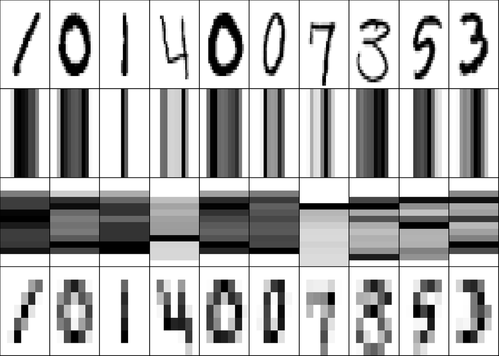

接著，針對這些資料分別DNN實驗，performance2 是原始資料+新features實驗結果，第一列是使用813個(785+28)features的結果，第二列是862個(785+28+49)features結果

```r
# 原始img
performance2 <- startDL(list(h2o_t0_add[, 1:813], h2o_t0_add))
# moveAVG img
performance3 <- startDL(list(h2o_t1_add[, 1:813], h2o_t1_add))
```

```r
performance2
```

```
##   mse_default acc_default  mse_tuning acc_tuning
## 1 0.001727918   0.9696605 0.002151548  0.9794125
## 2 0.001515546   0.9695401 0.002003862  0.9794125
```

performance3 是移動後平均資料+新features實驗結果。從以上結果看來，performance2 利用原始資料透過這些方法所增加的features並未帶來更佳的accuracy，結果和第一次的實驗差不多。反觀performance3 和其第一次實驗相比，透過增加 features的做法，在這次實驗中得到較佳的 accuracy (0.9815796)，而且和 performance2 相比，無論在使用預設或tuning參數上，其表現都比較好。因此，接下來的實驗，將以移動後平均資料+新features的資料做為base

```r
performance3
```

```
##   mse_default acc_default  mse_tuning acc_tuning
## 1 0.004745935   0.9717072 0.004810096  0.9798941
## 2 0.004694435   0.9711052 0.004509689  0.9815796
```

#### **Experiments (DNN + Feature Engineering + Auto-Encoder)**

前面提到H2O有支援Auto-Encoder，將autoencoder參數設為True即可使用，為了稍後繪圖查看，先自訂1層hidden layer 2個nodes，activation 參數設為Tanh(-1至1之間)

```r
y <- "label"
x <- setdiff(names(h2o_t1), y)
# Auto-Encoder: True
#2
model_2_AE <- h2o.deeplearning(x, training_frame = h2o_t1, autoencoder = T, hidden = c(2),
                             epochs = 50, activation = 'Tanh', seed = 777)
h2o.mse(model_2_AE)
feature_2_AE <- h2o.deepfeatures(model_2_AE,    h2o_t1, layer   =   1)
head(feature_2_AE)
```

model得到的mse和Auto-Encoder產生的2個features如下(前6筆資料)，看起來有點像是PCA、MDS概念，將784個features以2維來表示，不過Auto-Encoder會以比較平等方式來對待每個features，不像PCA的主成份通常cover了多數的features

```
## [1] 0.03470088
```

```
##     DF.L1.C1   DF.L1.C2
## 1  0.2196683  0.7518295
## 2 -0.7159596 -0.7618320
## 3  0.5903266  0.6224775
## 4  0.4880982 -0.1077478
## 5 -0.8151172 -0.8040580
## 6  0.0463586 -0.2727150
```

將產生的2維資料繪圖查看，很明顯的有些label確實集中在特定區域，表示這2個新features具有一些意涵

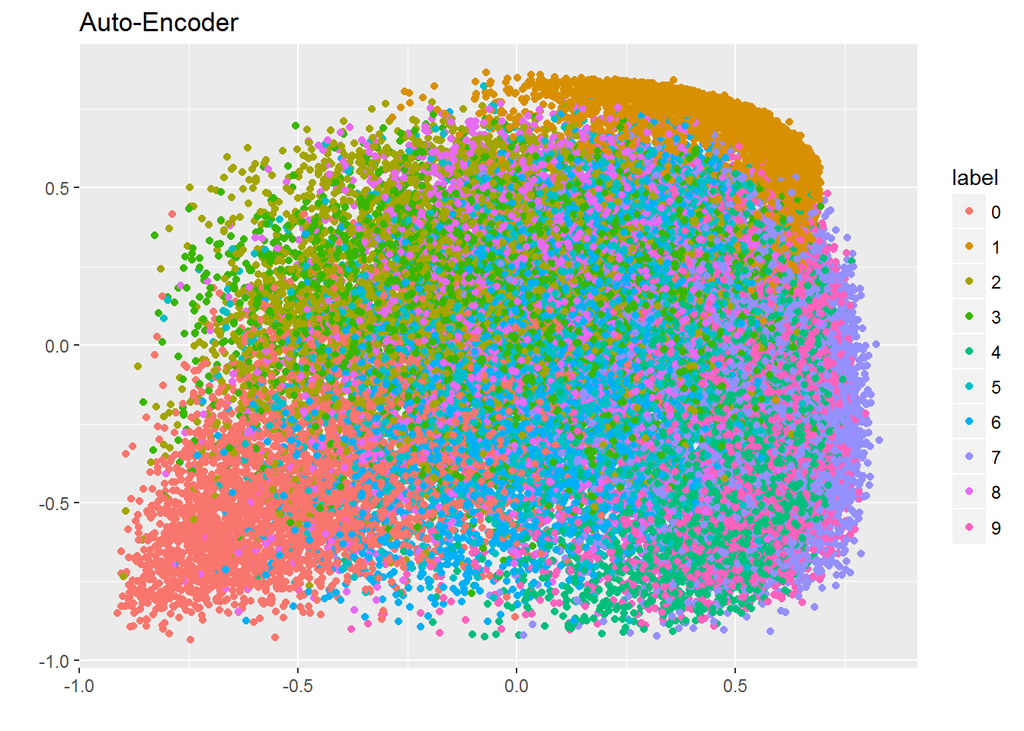

此外，也加入hidden layer size為5和10試試，其 mse 隨著size的增加而減少

```r
#5
model_5_AE <- h2o.deeplearning(x, training_frame = h2o_t1, autoencoder = T, hidden = c(5),
                             epochs = 50, activation = 'Tanh', seed = 777)
h2o.mse(model_5_AE)
feature_5_AE <- h2o.deepfeatures(model_5_AE,    h2o_t1, layer   =   1)
```

```
## [1] 0.02537029
```

```r
#10
model_10_AE <- h2o.deeplearning(x, training_frame = h2o_t1, autoencoder = T, hidden = c(10),
                               epochs = 50, activation = 'Tanh', seed = 777)
h2o.mse(model_10_AE)
feature_10_AE <- h2o.deepfeatures(model_10_AE,  h2o_t1, layer   =   1)
```

```
## [1] 0.0169034
```

最後，將這些Auto-Encoder產生的features加入，資料維度分別為864、867及872

```r
h2o_t1_add2AE <- h2o.cbind(h2o_t1_add, feature_2_AE)
h2o_t1_add5AE <- h2o.cbind(h2o_t1_add, feature_5_AE)
h2o_t1_add10AE <- h2o.cbind(h2o_t1_add, feature_10_AE)

dim(h2o_t1_add2AE)
dim(h2o_t1_add5AE)
dim(h2o_t1_add10AE)
```

```
## [1] 42000   864
```

```
## [1] 42000   867
```

```
## [1] 42000   872
```

再次進行DNN，從結果看來，本次第三列的結果最佳，tuning參數下的accuracy為0.9823020

```r
performance4 <- startDL(list(h2o_t1_add2AE, h2o_t1_add5AE, h2o_t1_add10AE))
```

```
##   mse_default acc_default  mse_tuning acc_tuning
## 1 0.004981815   0.9713460 0.004432200  0.9798941
## 2 0.004039633   0.9705033 0.003952557  0.9801348
## 3 0.005452700   0.9720684 0.004255208  0.9823020
```

#### **Summary**

這次實作了基本CV處理和H2O的DNN、Auto-Encoder，0.982的準確率看似不錯，但還是有改善的空間，不過最重要的是實作過程得到的啟發，下次將練習不同做法(如Ensemble方法)或是採用不同的Deep Learning套件(如Keras的CNN)，學海無涯，Learning by doing.

|  | mse_default | acc_default | mse_tuning | acc_tuning |
| --- | --- | --- | --- | --- |
| 2 | 0.0048562 | 0.9697809 | 0.0044490 | 0.9797737 |
| 21 | 0.0046944 | 0.9711052 | 0.0045097 | 0.9815796 |
| 3 | 0.0054527 | 0.9720684 | 0.0042552 | 0.9823020 |

### Lessons Learned:

#### Computer vision fundamentals

#### Deep Learning (H2O)